# Online FIPS

# Overview

In this notebook, we process the data from the online experiment studying Frame Induced Position Shift (FIPS).

Other resources for this project:

1. [OSF repository for the paper](https://osf.io/y5xrn/)
2. [Preprint of the paper](https://doi.org/10.1101/2021.01.23.427924)
3. [A demo version of the experiment](https://run.pavlovia.org/mthart/pubdemo/html/)

This Notebook is (generated from) an R markdown file that comes with an [RStudio Project stored on GitHub](http://github.com/thartbm/OnlineFIPS). It includes scripts that will download the raw data and reproduce the figures and analyses presented in the paper. The data will, surprisingly, be stored in the folder called ‘data’, and the R scripts are in a folder called ‘R’.

## Data

The data folder has a sub-folder called ‘Pavlovia’ that has one csv file for every run of the online experiment that was recorded. Some participants have apparently done the task twice (or more), some may not have finished the task and others may not appear in the questionnaire data. It will be filled from the [`data.zip`](https://osf.io/utyeh/download) file on the OSF repository.

The experiment was part of a battery of tasks that consisted of 2 sessions, each of which had tasks accessible from a Qualtrics questionnaire. We used the first session to collect demographics information and the FIPS task was part of the second session, with some pre- and post task questions to ensure quality of the data. Therefore we need data from both questionnaires. We do not provide the raw data here as it contains unnecessary information that might break anonymity, and it has a lot of irrelevant information. Instead we use one cleaned csv file with only the necessary information. This has double and incomplete entries removed as well.

## renv

To increase reproducibility, you can use the `renv` package to install the same versions of R packages that were used when making the RStudio Project (potentially a long time ago, so this is an attempt to ensure this code will work for a long time). They will be locally installed in the project directory and this may take some time and disk space. This R chunk will only be executed when you hit the green ‘run’ button on it.

The second line will interactively ask if you really want to install all the packages on the command line, which may be hidden.

```r
# this will attempt to get the same version of renv that was originally used:
source("renv/activate.R")
# which can then be used to install/restore the environment in which the scripts were run initially:
renv::restore()
```

## Analysis code

All functions to process the data are loaded here:

```r
# functions to select participants based on cursory inspection:
source('R/participants.R')
# functions to inspect / select participants based on task performance:
source('R/select.R')
# functions to do statistics:
source('R/statistics.R')
source('R/xtra.R')
# functions to create figures:
source('R/visualize.R')
```

## Online participants

First we examine all participants (both in the task data and the questionnaire data) to see which have useable data at first glance, and picks the latest full task run if there are multiple data files on Pavlovia:

```r
participants <- getParticipants()
str(participants)
```

```
## 'data.frame':    214 obs. of  12 variables:
##  $ participant    : chr  "219025" "218572" "219553" "220231" ...
##  $ finished       : chr  "True" "True" "True" "True" ...
##  $ redid          : chr  "No" "No" "No" "No" ...
##  $ distance_method: chr  "measured" "measured" "estimated" "skipped" ...
##  $ card_used      : chr  "No" "Yes" "Yes" "No" ...
##  $ age            : int  18 18 19 19 21 18 21 22 35 18 ...
##  $ sex            : chr  "Female" "Female" "Female" "Female" ...
##  $ handedness     : chr  "Right" "Right" "Right" "Right" ...
##  $ timestamp      : chr  "2020-10-20_20h50.56.349" "2020-10-20_21h34.17.296" "2020-10-20_21h34.18.848" "2020-10-20_21h44.58.202" ...
##  $ OS             : chr  "Win32" "MacIntel" "MacIntel" "Win32" ...
##  $ frameRate      : int  60 60 60 60 60 60 60 60 60 60 ...
##  $ completiontime : num  202.9 40.6 483.8 109.6 354.8 ...
```

This creates (overwrites) the file data/participants.csv, and returns information in it as a data frame. We can see that after removing participants based on questionnaire information or incomplete / multiple task files there are 214 left.

## Task data from selected participants

Then we can use the function `getFIPSdata()` to get the data in a more useful format. Let’s first write a csv file with only data from the 141 participants that pass our performance criteria:

```r
write.csv(getFIPSdata()[['FIPS']], 'data/onlineFIPS-141p.csv', row.names=F)
```

This file should be readable by many different kinds of software, such as a spreadsheet program.

# Effects of screen size and distance

For almost 50% of participants (69/141) we have reasonably reliable screen calibration data (viewing distance and pixel size in centimeters). First we look at a figure of the strength of the illusion (slope of a line fit to perceiced dot distance over frame movement amplitude in all 12 FIPS trials) as a function of how many degrees visual angle the frame subtends:

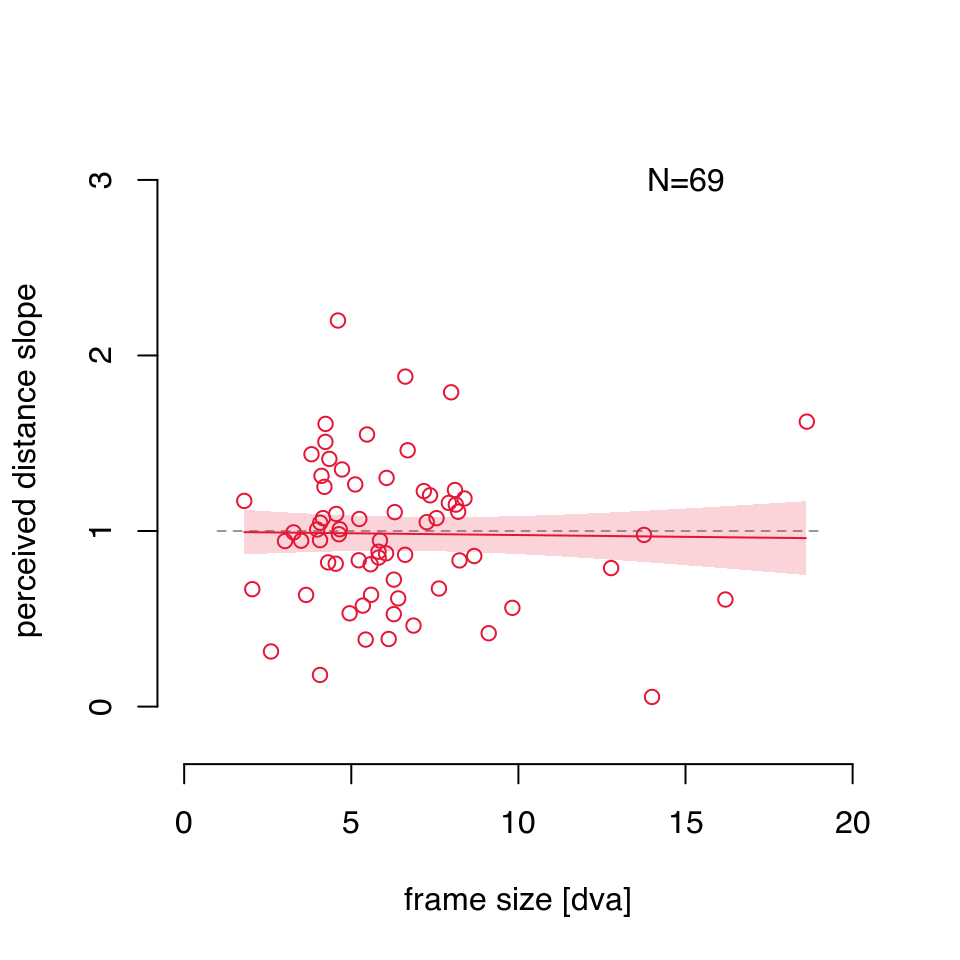

```r
plotDVAeffects()
```

Looks like there is no effect of retinal frame size on the strength of the illusion. In order to confirm this we run a Bayesian regression:

```r
DVAregression()
```

```
## Bayes factor analysis
## --------------
## [1] one_dva : 0.2542889 ±0%
##
## Against denominator:
##   Intercept only
## ---
## Bayes factor type: BFlinearModel, JZS
```

The Bayes Factor for the regression model is 0.254, which is moderate evidence for the null hypothesis (that retinal frame size does not affect illusion strength). So, we do not take this into account for any further analyses.

# Effects of frame movement speed and period over amplitude

First, let’s look at the data:

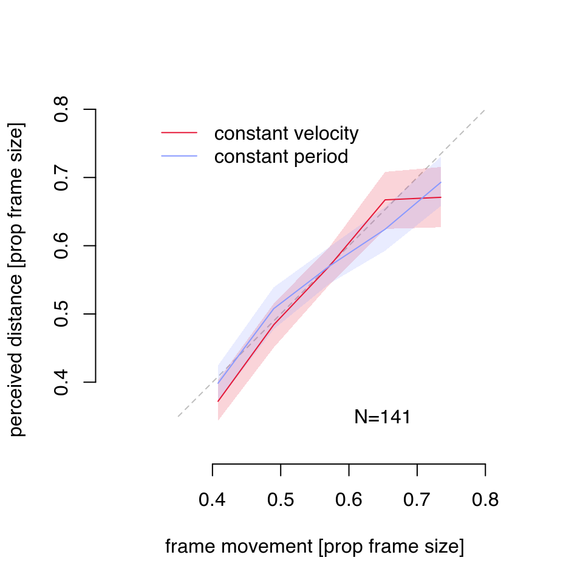

```r
plotFIPSpercepts()
```

This figure uses 95% confidence intervals, whereas in the paper we chose to use SEM. The perceived distance between the dots seems pretty close to the distance the frame travels (dashed gray line), no matter if we keep velocity constant (and vary period) or if we keep period constant (and vary velocity).

To test this, we run a Linear Mixed Effects model, with participant as a random effect, condition (categorical: constant velocity or period) and frame movement (numeric) as fixed effects. We use REML and a Nelder-Mead optimizer:

```r
LME <- FIPS_LME()
knitr::kable(coef(summary(LME)), digits=3)
```

|  | Estimate | Std. Error | df | t value | Pr(>\|t\|) |
| --- | --- | --- | --- | --- | --- |
| (Intercept) | 0.036 | 0.024 | 1200.583 | 1.484 | 0.138 |
| framedist | 0.910 | 0.037 | 1266.001 | 24.595 | 0.000 |
| cond1 | 0.029 | 0.022 | 1266.001 | 1.364 | 0.173 |
| framedist:cond1 | -0.046 | 0.037 | 1266.001 | -1.254 | 0.210 |

The distance the frame travels (framedist) predicts percept (t=24.6, p<.001) and has a coefficient of 0.91 which is getting pretty close to 1. There is no evidence that conditions contribute (t=1.4, p=.17) and they don’t interact with frame distance either (t=1.3, p=.21). That is, in the model, the distance the frame moves is sufficient to explain the perceived distance between the dots.

# Figures

The figures generated in this notebook can also be written to pdf or png files (more if you change the functions), which can be done here (turned off by default):

```r
target='png'
#target='pdf'
plotDVAeffects(target)
plotFIPSpercepts(target)
```

You will find the files in the `doc/` folder in the RStudio Project.

# Bayes Factors for lab experiments

Using a single wrapper function we can run ANOVAs and F-tests as well as their Bayesian variants to see if we can confirm the null-hypothesis (as opposed to only not rejecting it) for the lab experiments:

## Experiment 1: perceived distance between frame edges

Here participants seemed to perceive the distance between the two edges of the frame as the same, regardless of the length of the path that the frame travelled. Let’s see if the null can be confirmed:

```r
lab_NwayAOV(file='data/experiment_1.csv', within='path_length', printAOV = T)
```

```
## Anova Table (Type 3 tests)
##
## Response: percept
##        Effect          df  MSE    F  ges p.value
## 1 path_length 1.45, 10.16 4.26 2.65 .137    .127
## ---
## Signif. codes:  0 '***' 0.001 '**' 0.01 '*' 0.05 '+' 0.1 ' ' 1
##
## Sphericity correction method: GG
##
##
## A Bayes Factor version for the ANOVA:
```

```
## Bayes factor analysis
## --------------
## [1] path_length + participant : 1.558768 ±0.3%
##
## Against denominator:
##   percept ~ participant
## ---
## Bayes factor type: BFlinearModel, JZS
```

It seems the with a BF of 1.55 the data doesn’t support either hypothesis strongly.

## Experiment 2: effect of speed

Speed did not seem to affect the perceive distance between dots in experiment 2. Let’s see if we can confirm the null-hypothesis here:

```r
lab_NwayAOV(file='data/experiment2_speed.csv', within='speed', printAOV = T)
```

```
## Anova Table (Type 3 tests)
##
## Response: percept
##   Effect          df  MSE    F  ges p.value
## 1  speed 1.47, 10.28 9.29 2.01 .113    .186
## ---
## Signif. codes:  0 '***' 0.001 '**' 0.01 '*' 0.05 '+' 0.1 ' ' 1
##
## Sphericity correction method: GG
##
##
## A Bayes Factor version for the ANOVA:
```

```
## Bayes factor analysis
## --------------
## [1] speed + participant : 0.8884094 ±0.26%
##
## Against denominator:
##   percept ~ participant
## ---
## Bayes factor type: BFlinearModel, JZS
```

Again, with a BF of 0.89 the data doesn’t seem to support either hypothesis.

## Experiment 2: effect of frame size

The size of the frame did have a clear effect on the perceived distance between dots in experiment 2 either. Let’s see if we can replicate this here:

```r
lab_NwayAOV(file='data/experiment2_size.csv', within='size', printAOV = T)
```

```
## Anova Table (Type 3 tests)
##
## Response: percept
##   Effect          df  MSE         F  ges p.value
## 1   size 2.53, 17.68 1.03 11.17 *** .413   <.001
## ---
## Signif. codes:  0 '***' 0.001 '**' 0.01 '*' 0.05 '+' 0.1 ' ' 1
##
## Sphericity correction method: GG
##
##
## A Bayes Factor version for the ANOVA:
```

```
## Bayes factor analysis
## --------------
## [1] size + participant : 2001.32 ±0.44%
##
## Against denominator:
##   percept ~ participant
## ---
## Bayes factor type: BFlinearModel, JZS
```

The BF indeed replicates this finding as well.

## Experiment 2: constant speed and constant period conditions

```r
lab_NwayAOV(file='data/experiment2_frame_movement.csv', within=c('path_length', 'condition'), printAOV = T)
```

```
## Anova Table (Type 3 tests)
##
## Response: percept
##                  Effect          df  MSE          F  ges p.value
## 1           path_length 1.80, 12.58 2.96 120.92 *** .885   <.001
## 2             condition        1, 7 0.17   14.35 ** .029    .007
## 3 path_length:condition 2.16, 15.09 0.48    6.83 ** .077    .007
## ---
## Signif. codes:  0 '***' 0.001 '**' 0.01 '*' 0.05 '+' 0.1 ' ' 1
##
## Sphericity correction method: GG
##
##
## A Bayes Factor version for the ANOVA:
```

```
## Bayes factor analysis
## --------------
## [1] path_length + participant                                     : 9.71844e+34  ±0.53%
## [2] condition + participant                                       : 0.2589322    ±1.03%
## [3] path_length:condition + participant                           : 0.1267069    ±0.6%
## [4] path_length + condition + participant                         : 8.807211e+34 ±1.64%
## [5] path_length + path_length:condition + participant             : 1.180794e+35 ±0.7%
## [6] condition + path_length:condition + participant               : 0.03715835   ±13.78%
## [7] path_length + condition + path_length:condition + participant : 1.169299e+35 ±1.67%
##
## Against denominator:
##   percept ~ participant
## ---
## Bayes factor type: BFlinearModel, JZS
```